# DataCamp Assignment

This is a EdX Section 4 assignment completed on www.datacamp.com

## Adding required Libraries

```r
# Load the 'dslabs', 'pdlyr', 'ggplot2', 'tidyverse' packages.
library(dslabs)
library(dplyr)
library(ggplot2)
library(tidyverse)
```

## Exercise 1 - Heights Revisited

We have been using urn models to motivate the use of probability models. However, most data science applications are not related to data obtained from urns. More common are data that come from individuals. Probability plays a role because the data come from a random sample. The random sample is taken from a population and the urn serves as an analogy for the population.

Let’s revisit the heights dataset. For now, consider x to be the heights of all males in the data set. Mathematically speaking, x is our population. Using the urn analogy, we have an urn with the values of x in it.

What are the population average and standard deviation of our population?

### Instructions

- Execute the lines of code that create a vector x that contains heights for all males in the population.
- Calculate the average of x.
- Calculate the standard deviation of x

```r
# Load the 'dslabs' package and data contained in 'heights'
data(heights)

# Make a vector of heights from all males in the population
x <- heights %>% filter(sex == "Male") %>%
  .$height

# Calculate the population average. Print this value to the console.
mean(x)
```

```
## [1] 69.31475
```

```r
# Calculate the population standard deviation. Print this value to the console.
sd(x)
```

```
## [1] 3.611024
```

## Exercise 2 - Sample the population of heights

Call the population average computed above μ and the standard deviation σ. Now take a sample of size 50, with replacement, and construct an estimate for μ and σ.

### Instructions

- Use the sample function to sample N values from x.
- Calculate the mean of the sampled heights.
- Calculate the standard deviation of the sampled heights.

```r
# The vector of all male heights in our population `x` has already been loaded for you. You can examine the first six elements using `head`.
head(x)
```

```
## [1] 75 70 68 74 61 67
```

```r
# Use the `set.seed` function to make sure your answer matches the expected result after random sampling
set.seed(1)

# Define `N` as the number of people measured
N <- 50

# Define `X` as a random sample from our population `x`
X <- sample(x, replace=TRUE, size=N)

# Calculate the sample average. Print this value to the console.
mean(X)
```

```
## [1] 70.47293
```

```r
# Calculate the sample standard deviation. Print this value to the console.
sd(X)
```

```
## [1] 3.426742
```

## Exercise 4 - Confidence Interval Calculation

Construct a 95% confidence interval for μ.

### Instructions

- Use the sd and sqrt functions to define the standard error se
- Calculate the 95% confidence intervals using the qnorm function. Save the lower then the upper confidence interval to a variable called ci.

```r
# The vector of all male heights in our population `x` has already been loaded for you. You can examine the first six elements using `head`.
head(x)
```

```
## [1] 75 70 68 74 61 67
```

```r
# Use the `set.seed` function to make sure your answer matches the expected result after random sampling
set.seed(1)

# Define `N` as the number of people measured
N <- 50

# Define `X` as a random sample from our population `x`
X <- sample(x, N, replace = TRUE)

# Define `se` as the standard error of the estimate. Print this value to the console.
se <- sd(X) / sqrt(N)
se
```

```
## [1] 0.4846145
```

```r
# Construct a 95% confidence interval for the population average based on our sample. Save the lower and then the upper confidence interval to a variable called `ci`.
ci <- c(mean(X) - qnorm(0.975)*se, mean(X) + qnorm(0.975)*se)
```

## Exercise 5 - Monte Carlo Simulation for Heights

Now run a Monte Carlo simulation in which you compute 10,000 confidence intervals as you have just done. What proportion of these intervals include μ?

### Instructions

- Use the replicate function to replicate the sample code for `B <- 10000` simulations. Save the results of the replicated code to a variable called `res`. The replicated code should complete the following steps: -1. Use the sample function to sample `N` values from `x`. Save the sampled heights as a vector called `X`. -2. Create an object called interval that contains the 95% confidence interval for each of the samples. Use the same formula you used in the previous exercise to calculate this interval. -3. Use the between function to determine if $\mu$ is contained within the confidence interval of that simulation.
- Finally, use the mean function to determine the proportion of results in res that contain $\mu$.

```r
# Define `mu` as the population average
mu <- mean(x)

# Use the `set.seed` function to make sure your answer matches the expected result after random sampling
set.seed(1)

# Define `N` as the number of people measured
N <- 50

# Define `B` as the number of times to run the model
B <- 10000

# Define an object `res` that contains a logical vector for simulated intervals that contain mu

res <- replicate(B, {
    X <- sample(x, N, replace = TRUE)
    se <- sd(X) / sqrt(N)
    ci <- c(mean(X) - qnorm(0.975)*se, mean(X) + qnorm(0.975)*se)
    between(mean(x), ci[1], ci[2])
})

# Calculate the proportion of results in `res` that include mu. Print this value to the console.
mean(res)
```

```
## [1] 0.9479
```

## Exercise 6 - Visualizing Polling Bias

In this section, we used visualization to motivate the presence of pollster bias in election polls. Here we will examine that bias more rigorously. Lets consider two pollsters that conducted daily polls and look at national polls for the month before the election.

Is there a poll bias? Make a plot of the spreads for each poll.

### Instructions

- Use ggplot to plot the spread for each of the two pollsters.
- Define the x- and y-axes usingusing aes() within the ggplot function.
- Use geom_boxplot to make a boxplot of the data.
- Use geom_point to add data points to the plot.

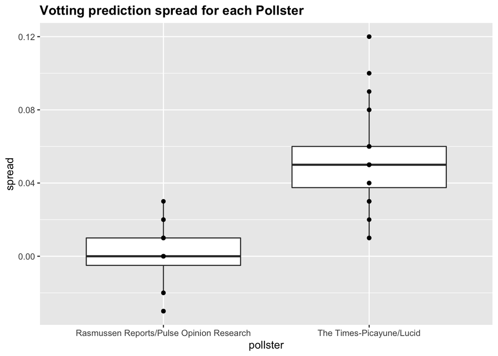

```r
# Load the libraries and data you need for the following exercises

data("polls_us_election_2016")

# These lines of code filter for the polls we want and calculate the spreads
polls <- polls_us_election_2016 %>%
  filter(pollster %in% c("Rasmussen Reports/Pulse Opinion Research","The Times-Picayune/Lucid") &
           enddate >= "2016-10-15" &
           state == "U.S.") %>%
  mutate(spread = rawpoll_clinton/100 - rawpoll_trump/100)

# Make a boxplot with points of the spread for each pollster
polls %>% ggplot(aes(x=pollster, y=spread)) +
    geom_boxplot() +
    geom_point() +
    ggtitle("Votting prediction spread for each Pollster") +
    theme(plot.title = element_text(lineheight=.8, face="bold"))
```

## Exercise 13 - Compute the Estimates

The answer to the previous question depends on $\sigma_1$ and $\sigma_2$, which we don’t know. We learned that we can estimate these values using the sample standard deviation.

Compute the estimates of $\sigma_1$ and $\sigma_2$.

### Instructions

- Group the data by pollster.
- Summarize the standard deviation of the spreads for each of the two pollsters. Name the standard deviation s.
- Store the pollster names and standard deviations of the spreads ($\sigma$) in an object called `sigma`.

```r
# The `polls` data have already been loaded for you. Use the `head` function to examine them.
head(polls)
```

```
##   state  startdate    enddate                                 pollster grade
## 1  U.S. 2016-11-05 2016-11-07                 The Times-Picayune/Lucid  <NA>
## 2  U.S. 2016-11-02 2016-11-06 Rasmussen Reports/Pulse Opinion Research    C+
## 3  U.S. 2016-11-01 2016-11-03 Rasmussen Reports/Pulse Opinion Research    C+
## 4  U.S. 2016-11-04 2016-11-06                 The Times-Picayune/Lucid  <NA>
## 5  U.S. 2016-10-31 2016-11-02 Rasmussen Reports/Pulse Opinion Research    C+
## 6  U.S. 2016-11-03 2016-11-05                 The Times-Picayune/Lucid  <NA>
##   samplesize population rawpoll_clinton rawpoll_trump rawpoll_johnson
## 1       2521         lv              45            40               5
## 2       1500         lv              45            43               4
## 3       1500         lv              44            44               4
## 4       2584         lv              45            40               5
## 5       1500         lv              42            45               4
## 6       2526         lv              45            40               5
##   rawpoll_mcmullin adjpoll_clinton adjpoll_trump adjpoll_johnson
## 1               NA        45.13966      42.26495        3.679914
## 2               NA        45.56041      43.13745        4.418502
## 3               NA        44.66353      44.28981        4.331246
## 4               NA        45.22830      42.30433        3.770880
## 5               NA        42.67626      45.41689        4.239500
## 6               NA        45.31041      42.34422        3.779955
##   adjpoll_mcmullin spread
## 1               NA   0.05
## 2               NA   0.02
## 3               NA   0.00
## 4               NA   0.05
## 5               NA  -0.03
## 6               NA   0.05
```

```r
# Create an object called `sigma` that contains a column for `pollster` and a column for `s`, the standard deviation of the spread
sigma <- polls %>%
    group_by(pollster) %>%
    summarise(s=sd(spread))

# Print the contents of sigma to the console
sigma
```

```
## # A tibble: 2 x 2
##   pollster                                      s
##   <fct>                                     <dbl>
## 1 Rasmussen Reports/Pulse Opinion Research 0.0177
## 2 The Times-Picayune/Lucid                 0.0268
```

## Exercise 15 - Calculate the 95% Confidence Interval of the Spreads

Construct a 95% confidence interval for the difference $b_1 - b_2$. Does this interval contain zero?

### Instructions

- Use pipes `%>%` to pass the data `polls` on to functions that will group by pollster and summarize the average spread, standard deviation, and number of polls per pollster.
- Calculate the estimate by subtracting the average spreads. Save this estimate to a variable called `estimate`.
- Calculate the standard error using the standard deviations of the spreads and the sample size. Save this value to a variable called `se_hat`. Calculate the `95%` confidence intervals using the qnorm function. Save the lower and then the upper confidence interval to a variable called `ci`.

```r
# The `polls` data have already been loaded for you. Use the `head` function to examine them.
head(polls)
```

```
##   state  startdate    enddate                                 pollster grade
## 1  U.S. 2016-11-05 2016-11-07                 The Times-Picayune/Lucid  <NA>
## 2  U.S. 2016-11-02 2016-11-06 Rasmussen Reports/Pulse Opinion Research    C+
## 3  U.S. 2016-11-01 2016-11-03 Rasmussen Reports/Pulse Opinion Research    C+
## 4  U.S. 2016-11-04 2016-11-06                 The Times-Picayune/Lucid  <NA>
## 5  U.S. 2016-10-31 2016-11-02 Rasmussen Reports/Pulse Opinion Research    C+
## 6  U.S. 2016-11-03 2016-11-05                 The Times-Picayune/Lucid  <NA>
##   samplesize population rawpoll_clinton rawpoll_trump rawpoll_johnson
## 1       2521         lv              45            40               5
## 2       1500         lv              45            43               4
## 3       1500         lv              44            44               4
## 4       2584         lv              45            40               5
## 5       1500         lv              42            45               4
## 6       2526         lv              45            40               5
##   rawpoll_mcmullin adjpoll_clinton adjpoll_trump adjpoll_johnson
## 1               NA        45.13966      42.26495        3.679914
## 2               NA        45.56041      43.13745        4.418502
## 3               NA        44.66353      44.28981        4.331246
## 4               NA        45.22830      42.30433        3.770880
## 5               NA        42.67626      45.41689        4.239500
## 6               NA        45.31041      42.34422        3.779955
##   adjpoll_mcmullin spread
## 1               NA   0.05
## 2               NA   0.02
## 3               NA   0.00
## 4               NA   0.05
## 5               NA  -0.03
## 6               NA   0.05
```

```r
# Create an object called `res` that summarizes the average, standard deviation, and number of polls for the two pollsters.
res <- polls %>%
    group_by(pollster) %>%
    summarise(avg = mean(spread),
              s = sd(spread),
              N = n())

# Store the difference between the larger average and the smaller in a variable called `estimate`. Print this value to the console.
estimate = max(res$avg) - min(res$avg)
estimate
```

```
## [1] 0.05229167
```

```r
# Store the standard error of the estimates as a variable called `se_hat`. Print this value to the console.
se_hat <- sqrt(sum((res$s^2)/res$N))
se_hat
```

```
## [1] 0.007031433
```

```r
# Calculate the 95% confidence interval of the spreads. Save the lower and then the upper confidence interval to a variable called `ci`.
ci <- c(estimate - qnorm(0.975)*se_hat, estimate + qnorm(0.975)*se_hat)
```

## Exercise 16 - Calculate the P-value

The confidence interval tells us there is relatively strong pollster effect resulting in a difference of about 5%. Random variability does not seem to explain it.

Compute a p-value to relay the fact that chance does not explain the observed pollster effect.

### Instructions

- Use the `pnorm` function to calculate the probability that a random value is larger than the observed ratio of the estimate to the standard error.
- Multiply the probability by 2, because this is the two-tailed test.

```r
# We made an object `res` to summarize the average, standard deviation, and number of polls for the two pollsters.
res <- polls %>% group_by(pollster) %>%
  summarize(avg = mean(spread), s = sd(spread), N = n())

# The variables `estimate` and `se_hat` contain the spread estimates and standard error, respectively.
estimate <- res$avg[2] - res$avg[1]
se_hat <- sqrt(res$s[2]^2/res$N[2] + res$s[1]^2/res$N[1])

# Calculate the p-value
2 * (1 - pnorm(estimate / se_hat))
```

```
## [1] 1.030287e-13
```

## Exercise 17 - Comparing Within-Poll and Between-Poll Variability

We compute statistic called the t-statistic by dividing our estimate of $b_1 - b_2$ by its estimated standard error:

Note that our data has more than two pollsters. We can also test for pollster effect using all pollsters, not just two. The idea is to compare the variability across polls to variability within polls. We can construct statistics to test for effects and approximate their distribution. The area of statistics that does this is called Analysis of Variance or ANOVA. We do not cover it here, but ANOVA provides a very useful set of tools to answer questions such as: is there a pollster effect?

Compute the average and standard deviation for each pollster and examine the variability across the averages and how it compares to the variability within the pollsters, summarized by the standard deviation.

### Instructions

- Group the `polls` data by pollster.
- Summarize the average and standard deviation of the spreads for each pollster.
- Create an object called `var` that contains three columns: pollster, mean spread, and standard deviation.
- Be sure to name the column for mean `avg` and the column for standard deviation `s`.

```r
# Execute the following lines of code to filter the polling data and calculate the spread
polls <- polls_us_election_2016 %>%
  filter(enddate >= "2016-10-15" &
           state == "U.S.") %>%
  group_by(pollster) %>%
  filter(n() >= 5) %>%
  mutate(spread = rawpoll_clinton/100 - rawpoll_trump/100) %>%
  ungroup()

# Create an object called `var` that contains columns for the pollster, mean spread, and standard deviation. Print the contents of this object to the console.
var <- polls %>%
    group_by(pollster) %>%
    summarise(avg = mean(spread),
              s = sd(spread))
var
```

```
## # A tibble: 11 x 3
##    pollster                                       avg       s
##    <fct>                                        <dbl>   <dbl>
##  1 ABC News/Washington Post                  0.0373   0.0339
##  2 CVOTER International                      0.0279   0.0180
##  3 Google Consumer Surveys                   0.0303   0.0185
##  4 Gravis Marketing                          0.0160   0.0152
##  5 IBD/TIPP                                  0.00105  0.0168
##  6 Ipsos                                     0.0553   0.0195
##  7 Morning Consult                           0.0414   0.0146
##  8 Rasmussen Reports/Pulse Opinion Research  0.000625 0.0177
##  9 The Times-Picayune/Lucid                  0.0529   0.0268
## 10 USC Dornsife/LA Times                    -0.0213   0.0207
## 11 YouGov                                    0.0398   0.00709
```